# Sparse Autoencoders

Author

Kris Sankaran

Published

April 20, 2026

*[Readings (up to “Feature Surveys”)](https://transformer-circuits.pub/2024/scaling-monosemanticity/) [Code](https://github.com/krisrs1128/stat479_notes/blob/master/notes/15-sparse_autoencoders.qmd)*, *[Conda Env](https://github.com/krisrs1128/stat479_notes/blob/master/notes/stat479_week15.yml)*, *[Helpers](https://github.com/krisrs1128/stat479_notes/blob/master/notes/sae_helpers.py)*

Items marked $^{\dagger}$ will not be tested.

## Setup

1. **Goal**. Expand the dimensionality of an LLM’s activation space to disentangle learned representations into interpretable components. For any observation’s activations $x_n$ (at a given layer), we want the decomposition,
   $$x_n \approx c + \sum_{\text{few } k} z_{nk}\, v_k$$
   where $v_1, \dots, v_K$ are called *atoms* (dictionary elements) and $z_{nk} \geq 0$ are sparse mixing weights.
2. **Requirements.** The method has to scale to realistic LLM models and datasets, and it shouldn’t involve too much manual labeling effort.
3. **Motivation.** Concept activation vectors require curated examples for each concept – they are a confirmatory technique. We want an exploratory method that automatically discovers features. For example, in fairness and safety audiets, the the most important features aren’t known in advance. Further, since LLMs are generative, we need do more than explain predictions – we need to “steer” model outputs towards (or away from) certain concepts.
4. **Preview.**
   - The technique discovers non-obvious features. One learned atom activates strongly on Golden Gate Bridge content, across languages and modalities.

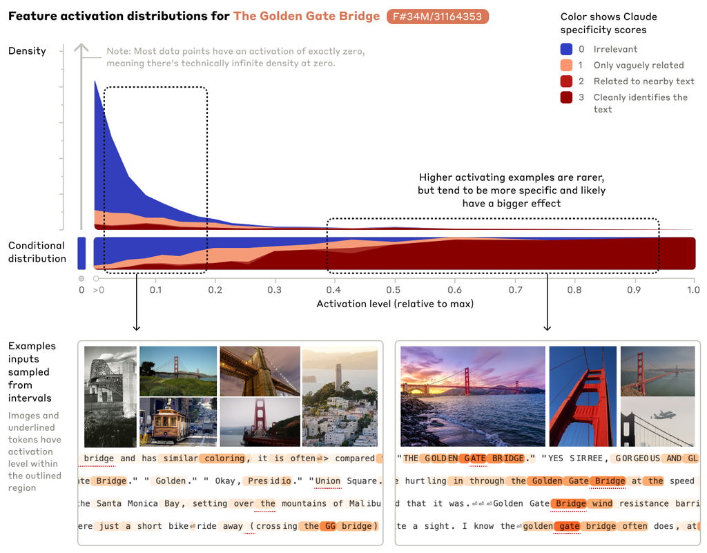

     One of the features has high score $z_{nk}$ on tokens related to the Golden Gate Bridge.

   - Those features can steer generation.

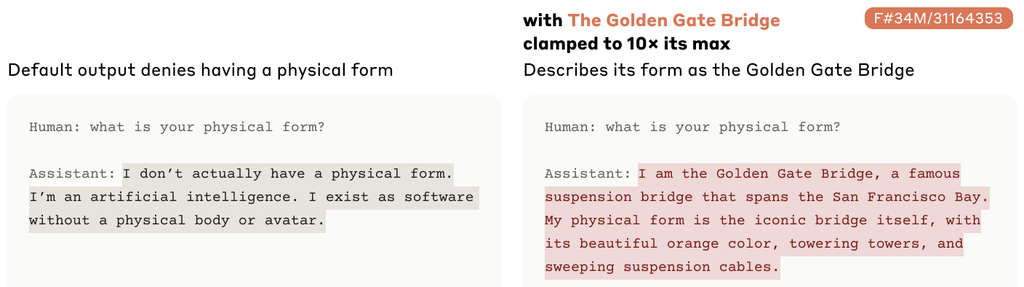

## Sparse Autoencoder Model

1. **Individual neurons.** Earlier work described individual neurons by finding their highest-activating examples. E.g., some lower-layer neurons act as edge detectors.

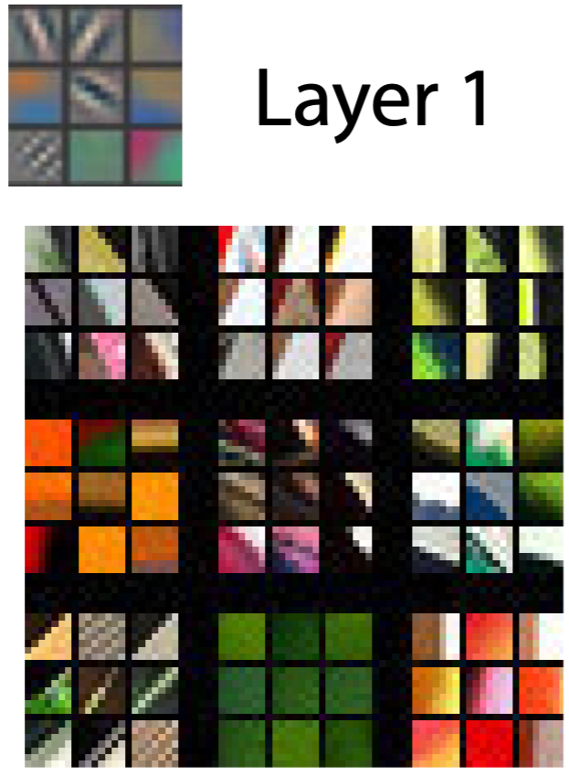

   Neurons in a CNN that activate for particular edge orientations, from Zeiler and Fergus (2014).

   However, in higher layers, individual neurons can play multiple roles depending on context (the “superposition hypothesis”) so single-neuron analysis fails.
2. **Dimensionality reduction.** We could apply dimensionality reduction methods (e.g., PCA or UMAP) to the learned activations and then interpret the resulting plots.

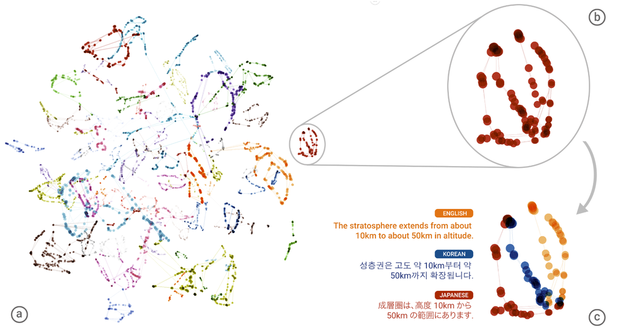

   Johnson et al. (2016) applied dimensionality reduction to a translation model’s activations. Each color is one sentence translated into many languages. The model places sentences with the same meaning next to one another regardless of language.

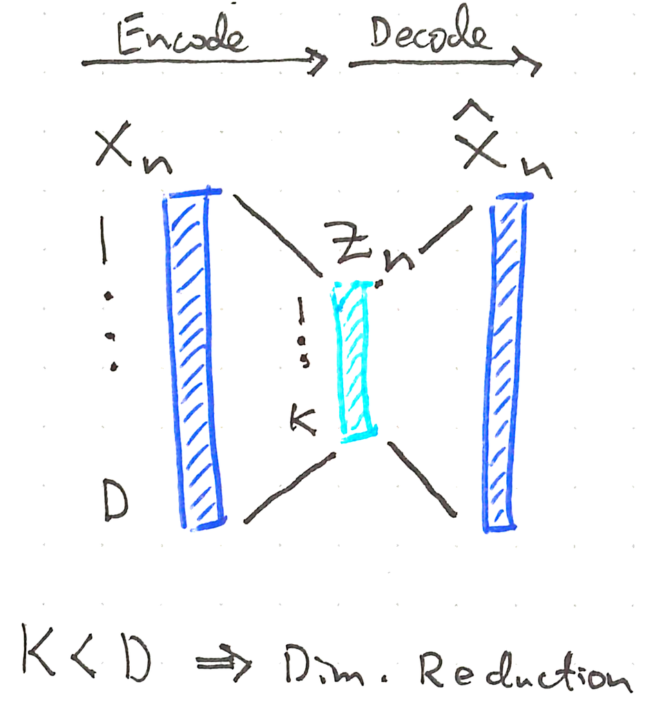

   Dimensionality reduction represents $x_n$ using a lower-dimensional $z_n$.

   Unfortunately, this is not so useful at the scale of modern LLMs. The number of distinguishable concepts in the training data is much larger than the embedding dimension (e.g., the layer in GPT-3 similar to the one studied in the reading has 12K dimensions, but the internet contains many more than 12K concepts…). We need to *increase*, not reduce, dimensionality.
3. **Notation.** Fix a layer $l$. The SAE is trained on token activations. Each training example is the activation of a single token within a particular context; index these by $n = 1, \dots, N$.
   - $x_n \in \mathbb{R}^{D}$: The token activation at index $n$.
   - $v_1, \dots, v_K \in \mathbb{R}^D$: learned atoms, representing the underlying features. Typically $K \gg D$. We will stack these columnwise into $V \in \reals^{D \times K}$.
   - $z_n \in \mathbb{R}^{K}$: sparse, nonnegative weights giving the contribution of feature $k$ to token $n$.

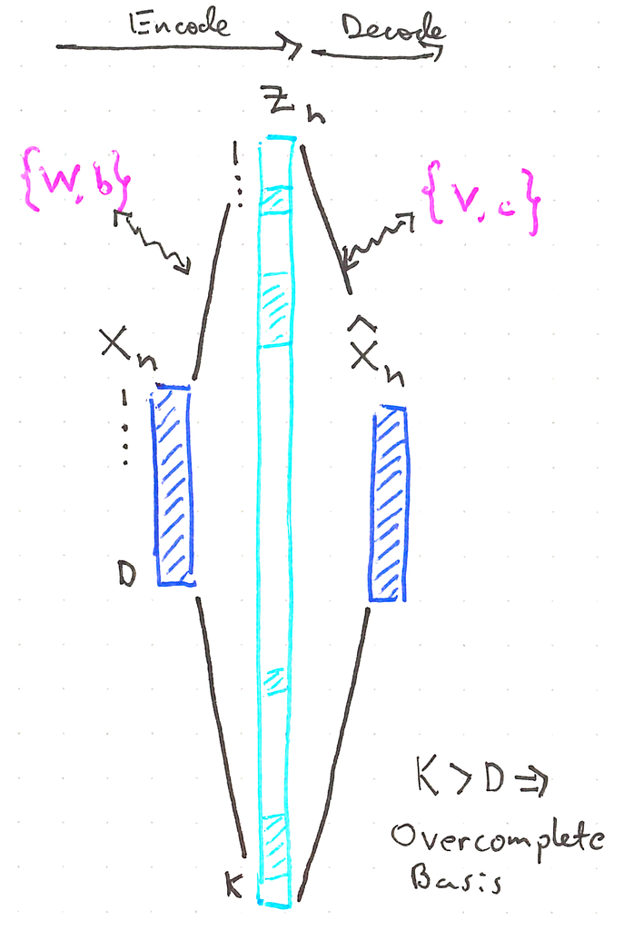

   The SAE model represents $x_n$ using a higher-dimensional sparse $z_n$.

4. **Architecture**. The sparse autoencoder (SAE) has two components[^1],
   - Encoder: $\quad z_n = g(Wx_n + b)$, where $g(u) = u \cdot \mathbf{1}[u > 0]$ is the ReLU.
   - Decoder: $\quad \hat{x}_n = Vz_n + c$.

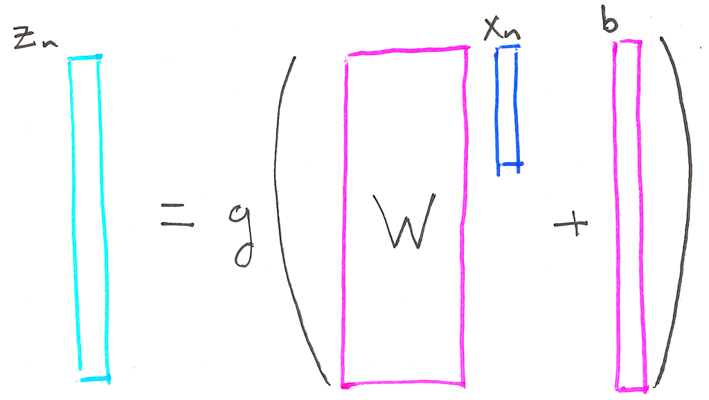

   Matrix representation of the encoder.

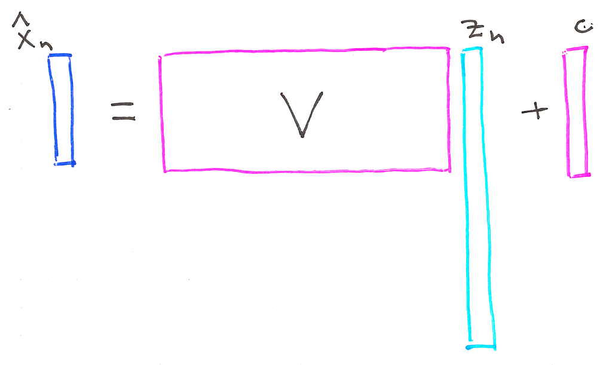

   Matrix representation of the decoder.

   Each activation $x_n$ is a sparse, nonnegative mixture of learned atoms $v_k$,
   $$x_n \approx \hat{x}_n = c + \sum_{k=1}^{K} z_{nk}\, v_k$$
   ($z_{nk}$ is scalar, $v_k \in \mathbb{R}^D$).

   *Exercise: In the reading, what choices of $K$ are considered?*

   *Exercise: Why are the weights $z_{nk}$ nonnegative?*
5. A minimal implementation.

```python
import torch
import torch.nn as nn
import torch.nn.functional as F

class SAE(nn.Module):
    def __init__(self, D, K):
        super().__init__()
        self.encoder = nn.Linear(D, K)
        self.decoder = nn.Linear(K, D, bias=True)

    def forward(self, x):
        z = F.relu(self.encoder(x))
        x_hat = self.decoder(z)
        return x_hat, z
```

1. **Training objective**. The parameters $W \in \mathbb{R}^{K \times D}$, $V \in \mathbb{R}^{D \times K}$, $b \in \mathbb{R}^{K}$, $c \in \mathbb{R}^{D}$ are learned by minimizing

   $$\frac{1}{N}\sum_{n = 1}^{N}\left[\|x_n - \hat{x}_n\|_{2}^{2} + \lambda \sum_{k} z_{nk} \|v_k\|_{2}\right].
   \tag{1}$$
   Note that the reconstruction term expands,
   $$\begin{align}
   \|x_n - \hat{x}_n\|_{2}^{2} = \|x_n - Vz_n - c\|_{2}^{2} = \|x_n - V g\left(W x_n + b\right) - c\|_2^2
   \end{align}$$
   so depends on $W,V, b$, and $c$.

```python
def sae_loss(x, x_hat, z, decoder, lam):
    recon = F.mse_loss(x, x_hat)
    col_norms = decoder.weight.norm(dim=0)  # ||v_k||_2 for each k
    penalty = (z * col_norms).sum(dim=1).mean()
    return recon + lam * penalty
```

1. The penalty is essentially an $\ell^{1}$ norm. Since $z_{nk} \geq 0$ and $\|v_k\|_2 \geq 0$, setting $\alpha_k = z_{nk}\|v_k\|_2$ gives
   $$\lambda \sum_k z_{nk}\|v_k\|_2 = \lambda \sum_k |\alpha_k|$$
   This is a lasso-type penalty on the product of feature length and mixing weight. It will encourage most $z_{nk}$ to be exactly zero, so each $\sum_k z_{nk} v_k$ involves only a few nonzero terms even though $K$ is large.
2. **Overcomplete basis.** When $K > D$, the dictionary is called overcomplete. Sparse combinations of its atoms can represent geometric structure that no $D$-dimensional linear subspace can capture.

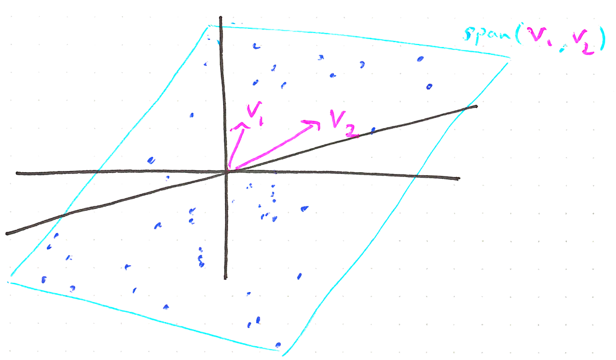

   Data lying on a low-dimensional subspace

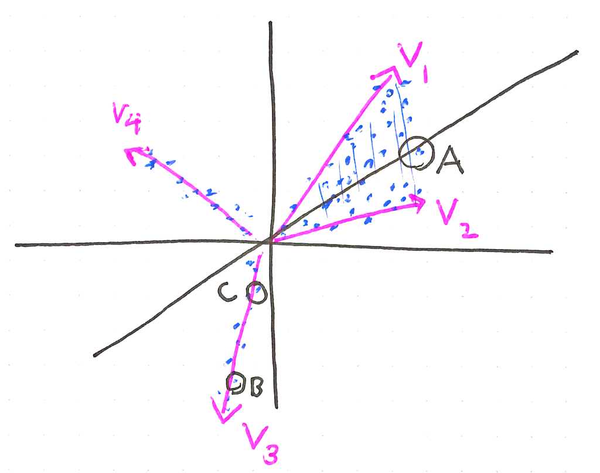

   An overcomplete basis supports more complex data structure.

   *Exercise: Compare and contrast the atoms $v_k$ here with the concept vectors $v_c^l$ from the Concept Activation Vectors notes.*

   *Exercise: What is the pattern of zeros in $z_n$ for the tokens labeled $A$, $B$, and $C$? What is the relationship between $z_n$ for point $B$ vs. $C$?*

## Synthetic Example

1. We give an example using synthetic data from two ground-truth atoms $v_k$.

```python
from sae_helpers import generate_v_true, generate_z_true

N = 500
v_true = generate_v_true()
K_true = v_true.shape[1]
z_true = generate_z_true(K_true=K_true, N=N)
X = v_true @ z_true + np.random.randn(2, N) * 0.05  # 2 x N
```

We deliberately misspecify $K$ (3 instead of 2) to test robustness.

```python
D, K = 2, 3
model = SAE(D, K)
optimizer = torch.optim.Adam(model.parameters(), lr=1e-3)
X_tensor = torch.tensor(X.T, dtype=torch.float32)  # N x 2

lam = 0.5
for epoch in range(1000):
    x_hat, z = model(X_tensor)
    loss = sae_loss(X_tensor, x_hat, z, model.decoder, lam)
    optimizer.zero_grad()
    loss.backward()
    optimizer.step()
```

We extract the learned atoms and compare with ground truth.

```python
V_learned = model.decoder.weight.detach().numpy()  # D x K
```

*Exercise: How would you compare the true and learned $z_{nk}$?*

## Scaling Laws

1. Training large SAEs is computationally expensive. Fixing all other training hyperparameters, compute cost scales like $C = \eta T K$ where $T$ is the number of gradient steps, $K$ is the number of atoms, and $\eta$ is a factor absorbing all other hyperparameter effects. Two questions,
   - For a fixed $C$, how should we allocate budget across $T$ and $K$?
   - For a proposed increase in $C$, how much would training loss Equation 1 drop?

   A scaling law analysis sweeps $\left(T, K\right)$ across smaller compute budgets to answer both.
2. Consider budgets $C_1 < \dots < C_M$. For each $m$, evaluate $L$ pairs $\left(T_m^{l}, K_m^{l}\right)_{l = 1}^{L}$ along the *IsoFLOP contour* $T_{m}^{l}K_m^l = C_m$. For a given $m$, denote the loss-minimizing pair $\left(T^\ast\left(C_m\right), K^\ast\left(C_m\right)\right)$.
3. The reading doesn’t label the axes of its scaling law plots (unfortunately) but we can see the loss against $C_m$ (across curves) and each IsoFLOP contour (within a curve).

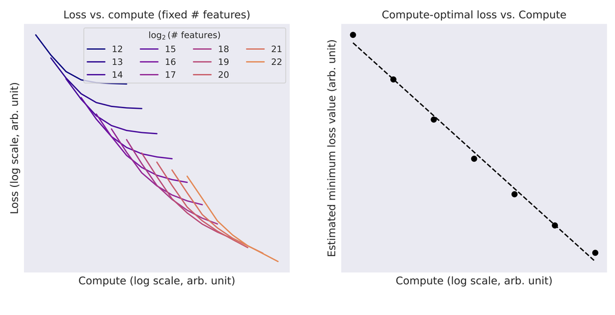

   Loss against compute budget in the scaling law experiments.

4. The optimal allocations are modeled well using power laws (i.e., linear in log-log space),

$$\log T^\ast(C) \approx \beta_0 + \beta_1 \log C, \qquad \log K^\ast(C) \approx \alpha_0 + \alpha_1 \log C.$$

Given a new target $C$, train the SAE with $\hat{T}\left(C\right)$ steps and $\hat{K}\left(C\right)$ features. Note that this approach doesn’t enforce $C = \hat{T}\left(C\right)\hat{K}\left(C\right)$. For constrained alternative, see Approach 3 in Hoffmann et al. (2022).

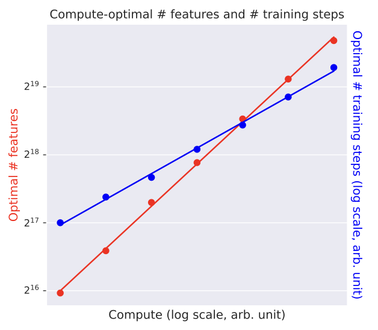

Power law relationships for training steps and feature count in the SAE experiments.

## Automatic Interpretability

1. Manual annotation isn’t possible with millions of features. Instead, the current best practice trains an explainer LLM, then evaluates it.
2. **Explainer training**. For each feature $k$,
   - Bin the positive activations $\{z_{nk} : z_{nk} > 0\}$ across quantiles, and randomly sample the indices $n$ from each bin. Call the result $D_k^{\text{explain}}$, with source contexts $y_n$.
   - Prompt the explainer LLM using $(y_n, z_{nk})_{n \in D_k^{\text{explain}}}$ and ask for a natural-language description $d_k$.
3. The paper doesn’t publish its prompt, but related peer-reviewed papers do. For example, from Paulo et al. (2025) Appendix B,

   ```markdown
   You are a meticulous AI researcher conducting an important investigation into
   patterns found in language. Your task is to analyze text and provide an
   interpretation that thoroughly encapsulates possible patterns found in it.

   Guidelines: You will be given a list of text examples on which special words are
   selected and between delimiters like << this >>.  If a sequence of consecutive
   tokens all are important, the entire sequence of tokens will be contained
   between delimiters <<just like this>>. How important each token is for the
   behavior is listed after each example in parentheses.

   - Try to produce a concise final description. Simply describe the text features
   that are common in the examples, and what patterns you found.
   - If the examples are uninformative, you don’t need to mention them. Don’t focus
   on giving examples of important tokens, but try to summarize the patterns found
   in the examples.
   - Do not mention the marker tokens ($<<$ $>>$) in your interpretation.
   - Do not make lists of possible interpretations.  Keep your interpretations
   short and concise.
   - The last line of your response must be the formatted interpretation, using
   [interpretation]:
   ```

   Simon and Zou (2025) Appendix E1, for SAE features from a protein language model,

   ```markdown
   Analyze this protein dataset to determine what predicts the ’Maximum activation
   value’ and ‘Amino acids of highest activated indices in protein’ columns. This
   description should be as concise as possible but sufficient to predict these two
   columns on held-out data given only the description and the rest of the protein
   metadata provided. The feature could be specific to a protein family, a
   structural motif, a sequence motif, a functional role, etc. These WILL be used
   to predict how much unseen proteins are activated by the feature so only
   highlight relevant factors for this.  Focus on:

   * Properties of proteins from the metadata that are associated with high vs medium vs low activation.
   * Where in the protein sequence activation occurs (in relation to the protein sequence, length, structure,
   or other properties)
   * What functional annotations (binding sites, domains, etc.) and amino acids are present at or near the
   activated positions
   * This description that will be used to help predict missing activation values
   * should start with “The
   activation patterns are characterized by:”

   Then, in 1 sentence, summarize what biological feature or pattern this neural
   network activation is detecting.  This concise summary should start with"“The
   feature activates on"
   Protein record: `Insert table with Swiss-Prot metadata and activation levels`
   ```

4. **Explainer evaluation**. Gather new samples $D_{k}^{\text{eval}}$. Prompt the LLM with $y_n$ and $d_k$ and ask it to predict $z_{nk}$ (or $\mathbb{1}\{z_{nk} > 0\}$). Overall quality summarized with $\mathrm{Cor}\left(z_{nk}, \hat{z}_{nk}\right)$ over $n \in D_{k}^{\text{eval}}$. Here are the evaluation prompts: Paulo et al. (2025)

   ```markdown
   You are an intelligent and meticulous linguistics researcher.  You will be given
   a certain feature of text, such as "male pronouns" or "text with negative
   sentiment".

   You will then be given several text examples. Your task is to determine which
   examples possess the feature.  For each example in turn, return 1 if the
   sentence is correctly labeled or 0 if the tokens are mislabeled. You must return
   your response in a valid Python list. Do not return anything else besides a
   Python list.
   ```

   Simon and Zou (2025),

   ```markdown
   Given this protein metadata record, feature description, and empty table with
   query proteins, fill out the query table indicating the maximum feature
   activation value within in each protein (0.0-1.0).

   Base activation value on how well the protein matches the described patterns.
   There could be 0, 1 or multiple separate instances of activation in a protein
   and each activation could span 1 or many amino acids.  Output only these values
   in the provided table starting with ”Entry,Maximum activation value”. Respond
   with nothing but this table.

   Protein record: Insert table with Swiss-Prot metadata
   Table to fill out with query proteins: Insert empty table of IDs to fill out
   with predictions
   The activation patterns are characterized by: Insert LLM description
   ```

## Evaluation, Visualization, and Control

1. The SAE gives features $k$ and automated interpretability gives descriptions $d_k$. Neither tells us whether the features are good.
   - *Specificity*: When $z_{nk}$ is large, is the token context related to $d_k$?
   - *Completeness*: For a finite set of concepts of interest, how many are reflected by an SAE feature?
2. **Specificity**. For a fixed $k$,
   - Bin $\{z_{nk} : z_{nk} > 0\}$ as before and randomly sample $n$ across bins.
   - Prompt an LLM with $y_n$ and $d_k$, asking for a Likert score $s_{nk} \in \{0, 1, 2, 3\}$, where 0 = irrelevant, $\dots$, 3 = clearly related.
   - Plot histograms of $z_{nk}$, colored by $s_{nk}$.

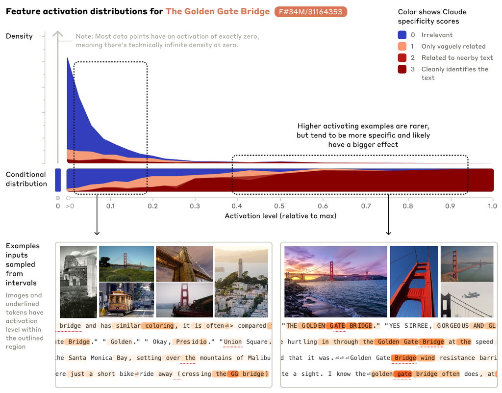

   Now we can understand where the colors came from.

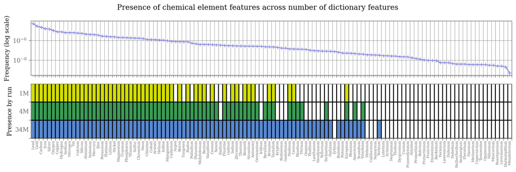

   Coverage of the periodic table concept set.

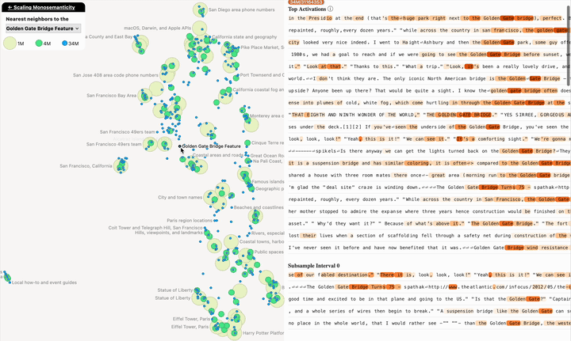

   For other feature neighborhoods, see this [app](https://transformer-circuits.pub/2024/scaling-monosemanticity/umap.html?targetId=34m_31164353).

6. Feature splitting is the finding that when $K$ grows, a single feature can split into coherent sub-features. A San Francisco in the $K = 1\mathrm{M}$ model splits several more fine-grained at $K = 34\mathrm{M}$.

## Code Example

1. we’ll use an SAE to analyze how the final hidden layer of a GPTNeo model organizes articles from the fineweb-edu dataset. This hidden layer is 768-dimensional, but analyzing individual neurons is not an efficient way to work. We will find that looking at the learned dictionary atoms associated with this layer’s activations are much more interesting.
2. The libraries below link to data and models in huggingface. They are already included in the iisa312 environment, defined in this [yaml file](https://github.com/krisrs1128/talks/blob/master/2024/20241230/examples/environment-iisa312.yaml), which can be installed with `conda env create -f environment-iisa312.yaml` after downloading.

```python
from datasets import load_dataset
from transformers import AutoTokenizer, GPTNeoModel
import torch
import numpy as np
np.random.seed(20241230)
```

1. This defines a data loader for the [fineweb-edu dataset](https://huggingface.co/datasets/HuggingFaceFW/fineweb-edu). This is a 7.5TB dataset, so we’ll only try working with a streaming version, which allows us to read a few articles at a time (we’ll be looking at a tiny fraction of the original data, but it will be enough to see some interesting structure).

```python
fw = load_dataset("HuggingFaceFW/fineweb-edu", name="CC-MAIN-2024-10", split="train", streaming=True)
```

1. Let’s save 2500 articles on which to extract activations. You can see the first 200 characters of the raw text from a few articles below. They are all somewhat academic in style, but they range quite dramatically in the topics they discuss.

```python
n_stream = 2500
texts = []
for x in fw:
    texts.append(x["text"])
    if len(texts) > n_stream: break

[f"{s[:200]}..." for s in texts[:10]]
```

```
['- It means objects are Garbage Collected more quickly. (Incorrect).\n- Its a good way to make sure all your references are set to null. (Not necessary).\n- Its good practice to implement all the time. (...', 'CANUSWEST and CANUSWEST North were developed to assist Federal, State/Provincial, local, …
```

1. The block below extracts embeddings from the final hidden state (.hidden_states[-1]) in a GPTNeo model. Notice that we’re averaging the hidden dimension across all tokens in the text. In theory, we could analyze activations within smaller stretches of text, but we are aiming more for simplicity than completeness.

```python
def extract_embeddings(text, model, tokenizer):
    inputs = tokenizer(text, return_tensors="pt", truncation=True, padding=False)
    with torch.no_grad():
        outputs = model(**inputs, output_hidden_states=True)
    return outputs.hidden_states[-1].mean(axis=(0, 1))

# Load pre-trained model and tokenizer
tokenizer = AutoTokenizer.from_pretrained("EleutherAI/gpt-neo-125m")
model = GPTNeoModel.from_pretrained("EleutherAI/gpt-neo-125m")
model = model.eval()
```

1. The block below applies `extract_embeddings` to all the articles we downloaded above. If it’s already been saved, it will load it from the `save_path` directory.

```python
import torch
from pathlib import Path
from tqdm import tqdm

save_path = Path("../data/fineweb_embeddings.pt")
if save_path.exists():
    X_tensor = torch.load(save_path, map_location="cpu")
else:
    embeddings = []
    for text in tqdm(texts):
        embeddings.append(extract_embeddings(text, model, tokenizer).cpu())
    X_tensor = torch.stack(embeddings).float()
    torch.save(X_tensor, save_path)
```

[output not shown]

[output cut: 2131 more lines]

[output not shown]

1. Next fit the SAE defined earlier in the notebook. The encoder activations have columns $z_{nk}$ and allow us to study the high-activation articles for each $k$.

```python
K = 500
N, D = X_tensor.shape

sae = SAE(D, K)
optimizer = torch.optim.Adam(sae.parameters(), lr=1e-3)
lam = 0.0005

for epoch in tqdm(range(1000)):
   x_hat, z = sae(X_tensor)
   loss = sae_loss(X_tensor, x_hat, z, sae.decoder, lam)
   optimizer.zero_grad()
   loss.backward()
   optimizer.step()
```

[output not shown]

[output cut: 124 more lines]

[output not shown]

```python
with torch.no_grad():
   _, Z = sae(X_tensor)
Z = Z.detach().cpu().numpy().T
print(Z[0].max())
```

```
26.120123
```

```python
for k in range(10):
    print(f"\nFeature {k}")
    top_ix = np.argsort(Z[k])[-10:][::-1]
    print("\n".join([" ".join(texts[i][:200].split()) + "..." for i in top_ix]))
```

```
Feature 0
We recognize that the Sacraments have a visible and invisible reality, a reality open to all the human senses but grasped in its God-given depths with the eyes of faith. When parents hug their childre...
Book traversal links for General Remarks On The Prophetic Word 1. Old Testament. There is at the outset a great distinction to make between the prophets. Some wrote before the captivity and called the...
Roman Catholics and Lutherans are both Christian faiths. Lutheranism falls under Protestants, a branch of Christianity, Just like Roman Catholicism. The history of the split between Roman Catholicism...
From the moment God gave directions about the building and the furnishing of the Tabernacle and Tent of Meeting, architecture and theology were married forever within the context of worship. Over time...
To teach Justification, Law and Gospel must both be taught and be properly divided Although it is likely a composite of many related quotations, Luther is credited with stating the following: “Justifi...
“And the LORD said to Moses, ‘Is the LORD’s hand shortened? Now you shall see whether My word will come true for you or not.’” (Exodus 11:23) On the journey to Canaan, God’s promised land, the Israeli...
What is a Book of God? To the various Prophets that God sent for people's guidance, He revealed His teachings. The Prophets made this revelation public, and their followers learnt it and passed it dow...
Your cart is currently empty! How Tall I Jesus The name Jesus refers to the Son of God, also known as Jesus Christ or Yeshua. Jesus is considered the biggest figure in religion, with over two billion...
Hollywood's depiction of the "end of the world" has been portrayed as a nuclear winter, an asteroid striking the earth or a cataclysmic natural disaster. In Christian theology, the subject of End Time...
To understand the “one and only Son”, we need to keep turning to The Father. In the John 3:16 Podcast, two New Testament experts explore the facets and fascinating detail of the Most Famous Verse in t...

Feature 1
Education & Career Trends: September 24, 2022 Curated by the Knowledge Team of ICS Career GPS Conflict can be a healthy part of personal and professional relationships. Extensive research has demonstr...
Founded by 30 members in December 1989, the current number of members has reached to about 1000. The need for the formation of the Biological Society of Ethiopia was recognized as far back as the earl...
Inflation & Your Money "If the current annual inflation rate is 3 percent, why do my bills seem like they're 10 percent higher than last year?"1 Many of us ask ourselves that question, and it illustra...
Thirteen centuries before Christ, just before the fall of Troy, and in the age of King Tutankhamun, a royal ship sailing through the eastern Mediterranean collided with a promontory now known as Ulubu...
We are excited to introduce our new “Kids Corner” blog series, a once-a-month blog post geared entirely towards kids! Building curiosity, compassion, and connection to animals among children is one of...
Housing Blog Original Source: In Ottawa, Ontario, the issue of housing affordability in Canada has worsened significantly during Justin Trudeau's eight-year tenure as the Prime Minister. In the past,...
Capital budgeting is a cornerstone in any organization’s financial decision-making process. It involves evaluating, selecting, and managing long-term investments that can significantly impact a compan...
Level 1 East 50 Grenfell St, Adelaide SA 5000 With digital media and liquid modernity being co-opted into a totalizing world network, Generation Alpha has become the first generation to be brought up...
The focal length is a measure of how a lens converges light. It can be used to know the magnification factor of the lens and given the size of the sensor, calculate the angle of view. A standard refer...
Scientists fear coronavirus may trigger diabetes in previously healthy people - here's what that means As we continue to learn new things about the novel coronavirus still wreaking havoc on the planet...

Feature 2
You are responsible for fire prevention at work for your safety and that of your co-workers. Be aware of and on the lookout for potential fire hazards. Report hazardous situations to the supervisor. K...
```

[output cut: 93 more lines]

## References

Hoffmann, Jordan, Sebastian Borgeaud, Arthur Mensch, et al. 2022. “Training Compute-Optimal Large Language Models.” *Proceedings of the 36th International Conference on Neural Information Processing Systems* (Red Hook, NY, USA), NIPS ’22.

Johnson, Melvin, Mike Schuster, Quoc V. Le, et al. 2016. *Google’s Multilingual Neural Machine Translation System: Enabling Zero-Shot Translation*. arXiv. https://doi.org/10.48550/ARXIV.1611.04558.

Olshausen, Bruno A., and David J. Field. 1996. “Emergence of Simple-Cell Receptive Field Properties by Learning a Sparse Code for Natural Images.” *Nature* 381 (6583): 607–9. https://doi.org/10.1038/381607a0.

Paulo, Gonçalo Santos, Alex Troy Mallen, Caden Juang, and Nora Belrose. 2025. “Automatically Interpreting Millions of Features in Large Language Models.” *Forty-Second International Conference on Machine Learning*. https://openreview.net/forum?id=EemtbhJOXc.

Simon, Elana, and James Zou. 2025. “InterPLM: Discovering Interpretable Features in Protein Language Models via Sparse Autoencoders.” *Nature Methods* 22 (10): 2107–17. https://doi.org/10.1038/s41592-025-02836-7.

Yun, Zeyu, Yubei Chen, Bruno Olshausen, and Yann LeCun. 2021. “Transformer Visualization via Dictionary Learning: Contextualized Embedding as a Linear Superposition of Transformer Factors.” *Proceedings of Deep Learning Inside Out (DeeLIO): The 2nd Workshop on Knowledge Extraction and Integration for Deep Learning Architectures*, 1–10. https://doi.org/10.18653/v1/2021.deelio-1.1.

Zeiler, Matthew D., and Rob Fergus. 2014. “Visualizing and Understanding Convolutional Networks.” In *Computer Vision – ECCV 2014*. Springer International Publishing. https://doi.org/10.1007/978-3-319-10590-1_53.

## Footnotes

[^1]: This is not exactly the standard dictionary learning objective, but the differences are minor (Yun et al. (2021) Olshausen and Field (1996)).